# HDAT9600 Final Team Assignment

*VIF values* 1. The VIF values common thresholds are 5 or 10, below that suggests that there isn’t a concerning level of multicollinearity among the main effects in the model. 1. High GVIF values for interaction terms are not uncommon, as these terms are products of their component variables and can inherit their collinearity. 2. High VIF/GVIF values do not imply that a model is invalid; rather, they suggest that the precision of the coefficient estimates for the related variables may be reduced.

```r
# Using dplyr to filter out cases where the specified variables are NA
#valid_data0 <- icu_patients_df0 %>% filter(!is.na(SAPS1) & !is.na(GCS_min) & !is.na(Creatinine_max))


# Logistic regression to see the effect of SAPS1 and SOFA scores on in-hospital death
model0_saps1 <- glm(in_hospital_death ~ SAPS1, data = icu_patients_df0_cleaned, family = binomial)
model0_sofa <- glm(in_hospital_death ~ SOFA, data = icu_patients_df0_cleaned, family = binomial)

# Predicted probabilities for the models
pred0_saps1 <- predict(model0_saps1, type = "response")
pred0_sofa <- predict(model0_sofa, type = "response")
pred0_fmodel <- predict(fmodel_df0_1, type = "response")
pred0_fmodel_TW <- predict(fmodel_df0_3, type = "response")

# Calculate Brier scores
Brier_model0_saps1 <- mean((pred0_saps1 - icu_patients_df0_cleaned$in_hospital_death)^2)
Brier_model0_sofa <- mean((pred0_sofa - icu_patients_df0_cleaned$in_hospital_death)^2)
Brier_fmodel_df0_1 <- mean((pred0_fmodel - icu_patients_df0_cleaned$in_hospital_death)^2)
Brier_fmodel_df0_3 <- mean((pred0_fmodel_TW - icu_patients_df0_cleaned$in_hospital_death)^2)

# Print Brier scores
cat("Brier score for SAPS1 Model: ", Brier_model0_saps1, "\n")
```

```
## Brier score for SAPS1 Model:  0.117486
```

```r
cat("Brier score for SOFA Model: ", Brier_model0_sofa, "\n")
```

```
## Brier score for SOFA Model:  0.1168699
```

```r
cat("Brier score for Final Model: ", Brier_fmodel_df0_1, "\n")
```

```
## Brier score for Final Model:  0.1008051
```

```r
cat("Brier score for Final Model with interaction terms: ", Brier_fmodel_df0_3, "\n")
```

```
## Brier score for Final Model with interaction terms:  0.1003641
```

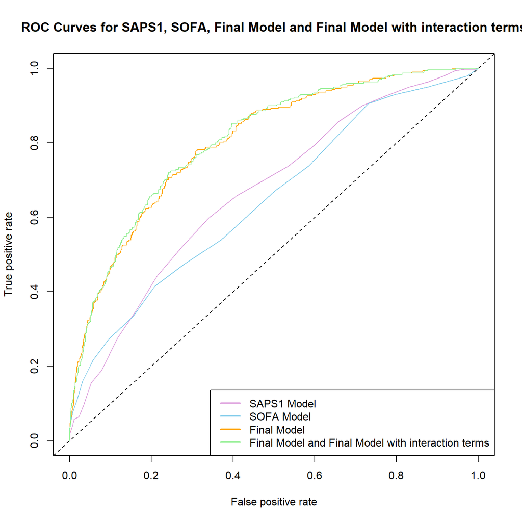

```r
# Create prediction objects for ROC analysis
pred0_obj_saps1 <- prediction(pred0_saps1, icu_patients_df0_cleaned$in_hospital_death)
pred0_obj_sofa <- prediction(pred0_sofa, icu_patients_df0_cleaned$in_hospital_death)
pred0_obj_fmodel <- prediction(pred0_fmodel, icu_patients_df0_cleaned$in_hospital_death)
pred0_obj_fmodel_TW <- prediction(pred0_fmodel_TW, icu_patients_df0_cleaned$in_hospital_death)

# Create performance objects for ROC analysis
perf0_saps1 <- performance(pred0_obj_saps1, "tpr", "fpr")
perf0_sofa <- performance(pred0_obj_sofa, "tpr", "fpr")
perf0_fmodel <- performance(pred0_obj_fmodel, "tpr", "fpr")
perf0_fmodel_TW <- performance(pred0_obj_fmodel_TW, "tpr", "fpr")


# Plot ROC curves
plot(perf0_saps1, col = "plum", main = "ROC Curves for SAPS1, SOFA, Final Model and Final Model with interaction terms")
plot(perf0_sofa, col = "skyblue", add = TRUE)
plot(perf0_fmodel, col = "orange", add = TRUE)
plot(perf0_fmodel_TW, col = "lightgreen", add = TRUE)
abline(a = 0, b = 1, lty = 2)

# Add a legend
legend("bottomright", legend = c("SAPS1 Model", "SOFA Model", "Final Model", "Final Model and Final Model with interaction terms"), col = c("plum", "skyblue", "orange", "lightgreen"), lwd = 2)
```

```r
# Calculate AUC for SAPS1 model
auc0_saps1 <- performance(pred0_obj_saps1, measure = "auc")
auc0_saps1_value <- auc0_saps1@y.values[[1]]
cat("AUC for SAPS1 Model:", auc0_saps1_value, "\n")
```

```
## AUC for SAPS1 Model: 0.6693982
```

```r
# Calculate AUC for SOFA model
auc0_sofa <- performance(pred0_obj_sofa, measure = "auc")
auc0_sofa_value <- auc0_sofa@y.values[[1]]
cat("AUC for SOFA Model:", auc0_sofa_value, "\n")
```

```
## AUC for SOFA Model: 0.6460789
```

```r
# Calculate AUC for Final model
auc0_fmodel <- performance(pred0_obj_fmodel, measure = "auc")
auc0_fmodel_value <- auc0_fmodel@y.values[[1]]
cat("AUC for Final Model:", auc0_fmodel_value, "\n")
```

```
## AUC for Final Model: 0.8032456
```

```r
# Calculate AUC for Final model with interaction terms
auc0_fmodel_TW <- performance(pred0_obj_fmodel_TW, measure = "auc")
auc0_fmodel_TW_value <- auc0_fmodel_TW@y.values[[1]]
cat("AUC for Final Model with interaction terms:", auc0_fmodel_TW_value, "\n")
```

```
## AUC for Final Model with interaction terms: 0.8074798
```

*Interpretations:* **Brier Score**: Lower Brier scores indicate better model calibration, where the predicted probabilities are closer to the actual outcomes. Both full models show better performance than the simpler SAPS1 and SOFA models, with the interaction-inclusive model (Full Model 3) slightly outperforming Full Model 1.

**AUC**: Higher AUC values indicate better discriminative ability, i.e., the model’s ability to distinguish between patients who survived and those who did not. Similar to the Brier scores, the full models show superior performance, with the interaction-inclusive model demonstrating the highest AUC.

**Conclusions of analysis and ROC Curves**: - SAPS1 and SOFA models, while simpler and less computationally intensive, do not perform as well as the full models, which justifies the inclusion of additional predictors and interactions to improve model accuracy. - The improvement from “Final Model” to “Final Model with interaction terms” is marginal but consistent across both metrics, reinforcing the potential utility of these interaction terms in predicting patient outcomes. - “Final Model with interaction terms”, which includes interactions, performs the best in terms of both calibration (Brier score) and discrimination (AUC), suggesting that including interaction terms between SOFA and pH_diff and SOFA and WBC_max may capture important complexities in the data that relate to the likelihood of in-hospital death.

### Interpretation:

- The **inclusion of interaction terms** in final model provides a meaningful improvement, albeit slight, suggesting that the interactions between SOFA scores and both pH differences and WBC counts are relevant in predicting patient outcomes in the dataset.
- This improvement, while modest, could be clinically significant, especially in a setting where predicting patient outcomes can help tailor interventions more effectively.

# Task 2

### Part A: Exploratory Data Analysis

The goal of this EDA is similar to Task 1 and you may choose to use the same sub-set of predictors if they are relevant and appropriate to the analysis for Task 2. You may also choose to select a different sub-set if you wish. Justify whichever approach you choose.

Present enough information to: (i) explain why you selected these variables, and (ii) Provide an overview of the variables and how they are related to survival. Present your summary using tables and/or plots with supporting commentary where relevant.

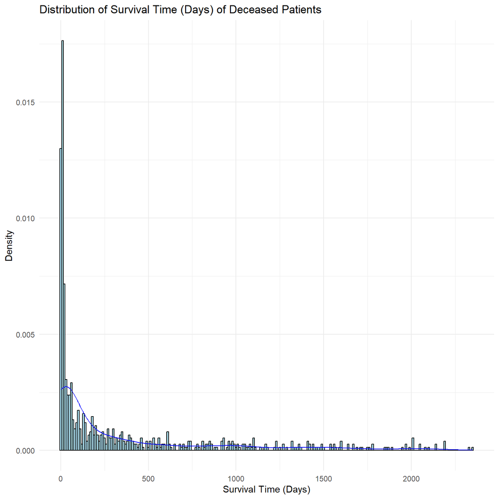

```r
# Convert days to years for the survival analysis
icu_patients_df1_cleaned$Years <- icu_patients_df1_cleaned$Days / 365.25
# Filter out the maximum 'Days' value for a clearer histogram via focus on deceased patients
# **In data instraction "ICU stays of less than 48 hours have been excluded.", But I still see the 1 and 2 days value in `Days` variable.
filtered_2days_data <- icu_patients_df1_cleaned %>% filter(Days >= 2)
filtered_days_data <- icu_patients_df1_cleaned %>% filter(Days >= 2 & Days < 2408)
#all(icu_patients_df1_cleaned$Days[icu_patients_df1_cleaned$Status == 'FALSE'] == 2408) #Return TRUE if all entries in icu_patients_df1 where the Status is FALSE have the Days value of 2408.

# Histogram of survival time with density line
ggplot(filtered_days_data, aes(x = Days)) +
  geom_histogram(aes(y = after_stat(density)), binwidth = 10, fill = "skyblue", color = "black", alpha = 0.7) +
  geom_density(color = "blue") +
  labs(title = "Distribution of Survival Time (Days) of Deceased Patients",
       x = "Survival Time (Days)",
       y = "Density") +
  theme_minimal()
```

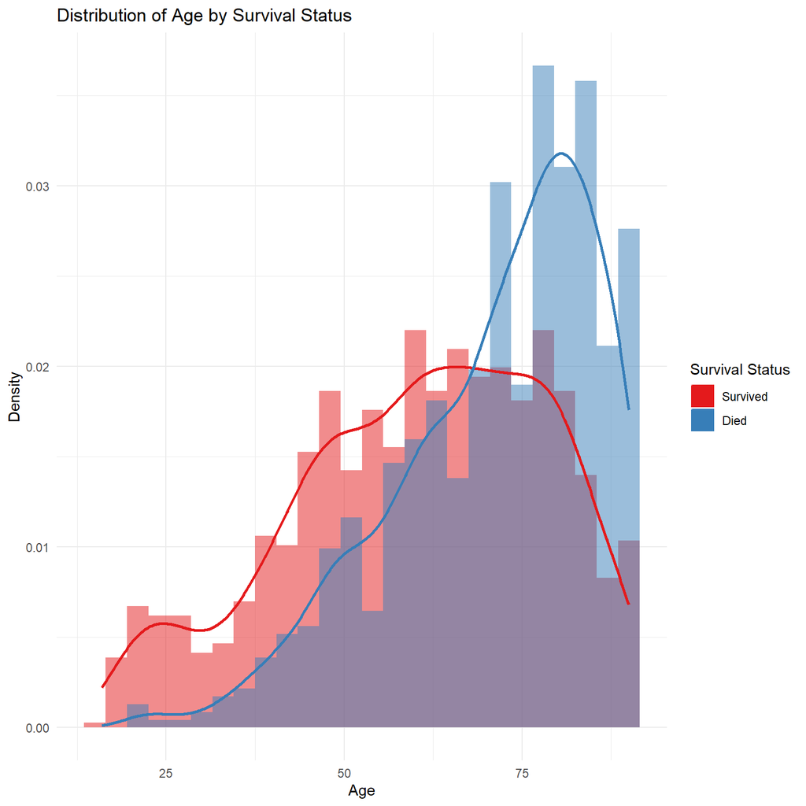

```r
# Histogram of patient ages with density line
# Transform the 'Status' logical variable into a factor with levels 'Survived' and 'Died'
icu_patients_df1_cleaned$Survival_Status <- factor(icu_patients_df1_cleaned$Status, levels = c(FALSE, TRUE), labels = c("Survived", "Died"))

ggplot(icu_patients_df1_cleaned, aes(x = Age, y = after_stat(density))) +
  geom_histogram(aes(fill = Survival_Status), position = "identity", binwidth = 3, alpha = 0.5, na.rm = TRUE) +
  scale_fill_brewer(palette = "Set1", name = "Survival Status") +
  geom_density(aes(color = Survival_Status), linewidth = 1, na.rm = TRUE) +
  labs(title = "Distribution of Age by Survival Status",
       x = "Age",
       y = "Density") +
  theme_minimal() +
  scale_color_brewer(palette = "Set1", name = "Survival Status")
```

**Distribution of Survival Time (Days) of Deceased Patients**: - A heavy concentration of data at the lower end of the survival time spectrum, indicating that a significant number of patients unfortunately passed away shortly after their ICU admission. - If including values at 2408 days, the presence of a sharp peak at the far right end could indicate right-censoring at a study endpoint or a standard follow-up period.

**Distribution of All Patient Age**: - The distribution of ages among patients who survived (represented by the red bars and density curve) spans a broad range, and there’s a notable peak around the middle age range. - The distribution of ages among patients who died (depicted by the blue bars and density curve) also covers a wide age range but with a peak at an older age, indicating older patients possibly having a higher risk of mortality.

```r
# Survival status frequency and proportion table
status_table <- table(icu_patients_df1_cleaned$Status)
status_prop <- prop.table(status_table) * 100  # Convert to percentages
status_df <- data.frame(
  Status = c("Survived", "Deceased"),
  Frequency = as.integer(status_table),
  Proportion = sprintf("%.2f%%", status_prop)
)
kable(status_df, caption = "Survival Status of Patients", row.names = FALSE)
```

Survival Status of Patients

| Status | Frequency | Proportion |
| --- | --- | --- |
| Survived | 1288 | 62.49% |
| Deceased | 773 | 37.51% |

```r
# Summaries for continuous variables (Days)
days_summary <- summary(filtered_days_data$Days)
days_summary_df <- data.frame(
  Statistic = c("Minimum", "1st Quartile", "Median", "Mean", "3rd Quartile", "Maximum"),
  Value = c(days_summary[c(1,2,3,4,5,6)])
)
kable(days_summary_df, caption = "Summary of Survival Time (Days) of Deceased Patients")
```

Summary of Survival Time (Days) of Deceased Patients

|  | Statistic | Value |
| --- | --- | --- |
| Min. | Minimum | 2.0000 |
| 1st Qu. | 1st Quartile | 11.0000 |
| Median | Median | 77.0000 |
| Mean | Mean | 348.5013 |
| 3rd Qu. | 3rd Quartile | 445.5000 |
| Max. | Maximum | 2350.0000 |

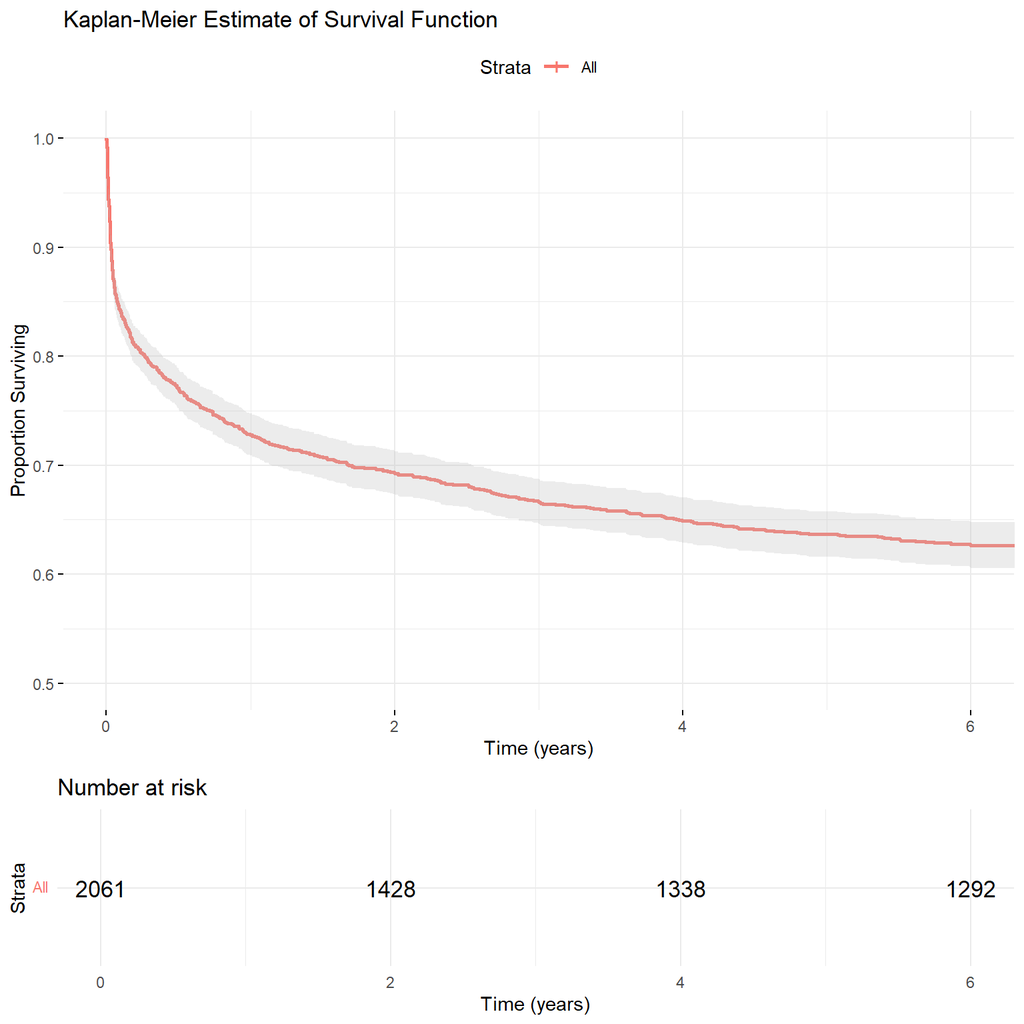

```r
# Creating the survival object
surv_obj <- Surv(time = icu_patients_df1_cleaned$Days, event = icu_patients_df1_cleaned$Status)
surv_obj_years <- Surv(time = icu_patients_df1_cleaned$Years, event = icu_patients_df1_cleaned$Status)

# Fitting the Kaplan-Meier survival model
surv_fit <- survfit(surv_obj ~ 1)  # `~ 1` for an overall curve
surv_fit_years <- survfit(surv_obj_years ~ 1, data = icu_patients_df1_cleaned)
surv_fit_ICUtype <- survfit(surv_obj_years ~ ICUType, data = icu_patients_df1_cleaned)

# Plot the overall Kaplan-Meier survival curve
ggsurvplot(surv_fit_years, data = icu_patients_df1_cleaned,
  conf.int = TRUE,  risk.table = TRUE, # Display the confidence interval and risk table
  xlab = "Time (years)", ylab = "Proportion Surviving", title = "Kaplan-Meier Estimate of Survival Function", ylim = c(0.5, 1),
  surv.median.line = "hv",  # Add a horizontal line at the median
  ggtheme = theme_minimal()  # Use a minimal theme for a cleaner look
)
```

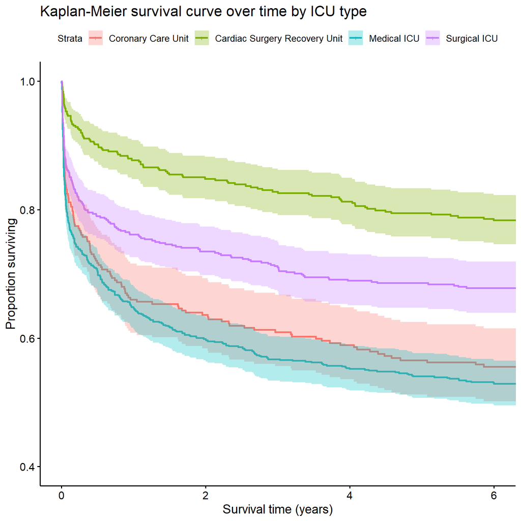

```r
#Kaplan Meier curve by ICU types
ggsurvplot(surv_fit_ICUtype, data=icu_patients_df1_cleaned,  conf.int = TRUE,  censor.size=2, risk.table = FALSE, legend.labs = c("Coronary Care Unit", "Cardiac Surgery Recovery Unit", "Medical ICU", "Surgical ICU"), ylim = c(0.4,1.0),) +
   xlab("Survival time (years)") + ylab("Proportion surviving")+ ggtitle("Kaplan-Meier survival curve over time by ICU type")
```

### Part B: Explanatory survival model

Your aim is to try to understand and EXPLAIN how survival time varies by `Age`. How does survival change with increasing Age? Can any age-related differences in survival time be explained by differing clinical presentations of older patients?

In this task, you are required to develop a Cox proportional hazards survival model using the `icu_patients_df1` data set which adequately **explains** the length of survival indicated by the `Days` variable, with censoring as indicated by the `Status` variable. You should fit a univariable model examining the relationship between Age and survival. You should then also fit another one or two multivariable models, to examine the extent that survival is explained by other variables in the dataset and whether age is independently related to survival after controlling for other factors. Your final model should **not** include all the predictor variables, just a relevant subset of them, which you have selected based on statistical significance and/or background knowledge. It is perfectly acceptable to include predictor variables in your final model which are not statistically significant, as long as you justify their inclusion on medical or physiological grounds (you will not be marked down if your medical justification is not exactly correct, but do you best). You should assess each model you consider for goodness of fit and other relevant statistics, and you should assess your final model for violations of assumptions and perform other diagnostics which you think are relevant (and modify the model if indicated, or at least comment on the possible impact of what your diagnostics show).

Finally, re-fit your final model to the unimputed data frame (`icu_patients_df0.rds`) and comment on any differences you find.

**Create your response to task 2 here, as a mixture of embedded (`knitr`) R code and any resulting outputs, and explanatory or commentary text. Add code chunks as you see fit and choose whether you wish for the code and or results to be displayed in the final html document.**

```r
cox_model_age <- coxph(Surv(Days, Status) ~ Age, data = icu_patients_df1_cleaned)
summary(cox_model_age)
```

```
## Call:
## coxph(formula = Surv(Days, Status) ~ Age, data = icu_patients_df1_cleaned)
##
##   n= 2061, number of events= 773
##
##        coef exp(coef) se(coef)     z Pr(>|z|)
## Age 0.03355   1.03412  0.00250 13.42   <2e-16 ***
## ---
## Signif. codes:  0 '***' 0.001 '**' 0.01 '*' 0.05 '.' 0.1 ' ' 1
##
##     exp(coef) exp(-coef) lower .95 upper .95
## Age     1.034      0.967     1.029     1.039
##
## Concordance= 0.646  (se = 0.01 )
## Likelihood ratio test= 209.4  on 1 df,   p=<2e-16
## Wald test            = 180.1  on 1 df,   p=<2e-16
## Score (logrank) test = 187  on 1 df,   p=<2e-16
```

```r
cox_model_age2 <- coxph(Surv(Days, Status) ~ Age, data = filtered_2days_data) # not sure if we should exclude < 2 days data as "ICU stays of less than 48 hours have been excluded."
summary(cox_model_age2)
```

```
## Call:
## coxph(formula = Surv(Days, Status) ~ Age, data = filtered_2days_data)
##
##   n= 2043, number of events= 755
##
##         coef exp(coef) se(coef)     z Pr(>|z|)
## Age 0.034403  1.035002 0.002543 13.53   <2e-16 ***
## ---
## Signif. codes:  0 '***' 0.001 '**' 0.01 '*' 0.05 '.' 0.1 ' ' 1
##
##     exp(coef) exp(-coef) lower .95 upper .95
## Age     1.035     0.9662      1.03      1.04
##
## Concordance= 0.649  (se = 0.01 )
## Likelihood ratio test= 213.7  on 1 df,   p=<2e-16
## Wald test            = 183  on 1 df,   p=<2e-16
## Score (logrank) test = 190.4  on 1 df,   p=<2e-16
```

**Coefficient (Age):** The coefficients in model are positive indicating that with additional year of age, risk of the event (death) increased. **Hazard Ratio (exp(coef)):** Each additional year of age increases the risk of death by approximately 3.5% **Concordance:** It measures the model’s predictive accuracy 0.65 suggest a moderate predictive ability **Statistical Tests:** All three statistical tests (Likelihood ratio test, Wald test, and Score (logrank) test) confirm the significant relationship between age and survival in both models.

*task2.B_2 Multivariable Cox Models Creating Checking and Selection*

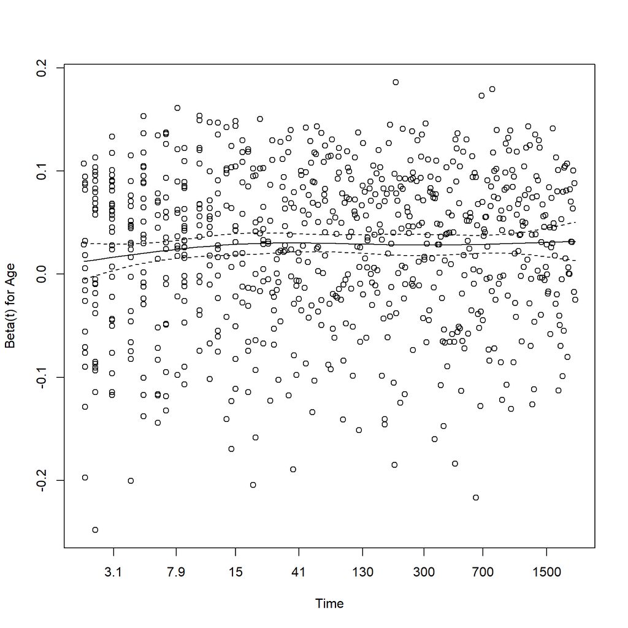

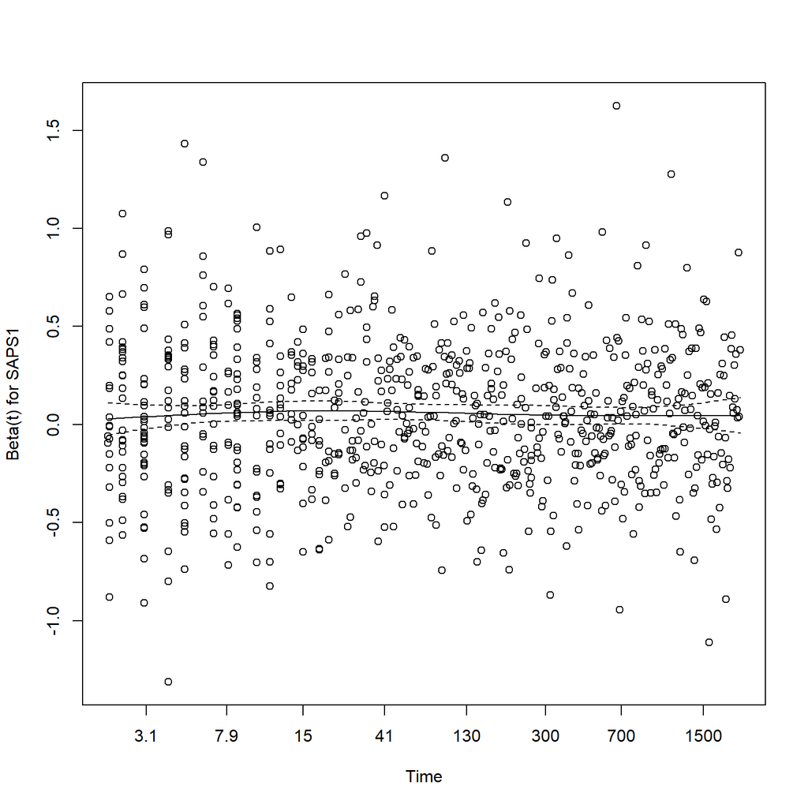

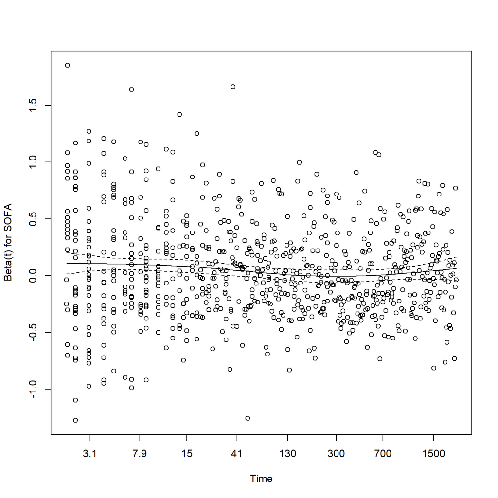

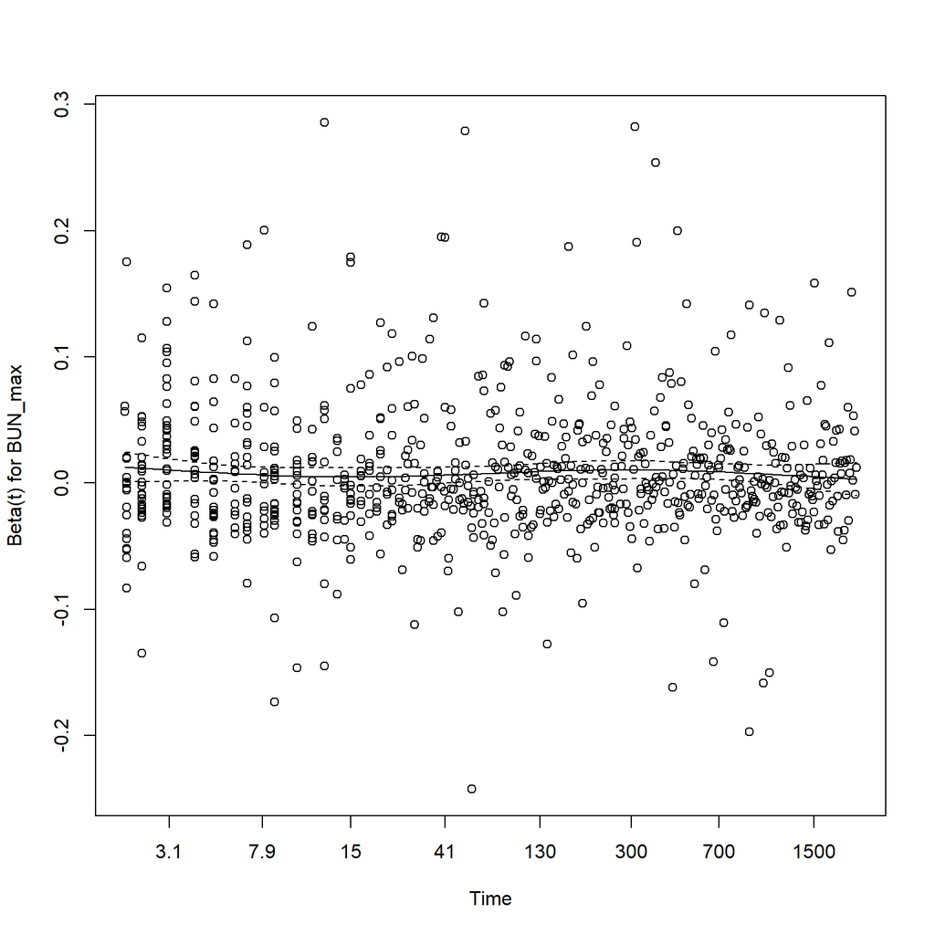

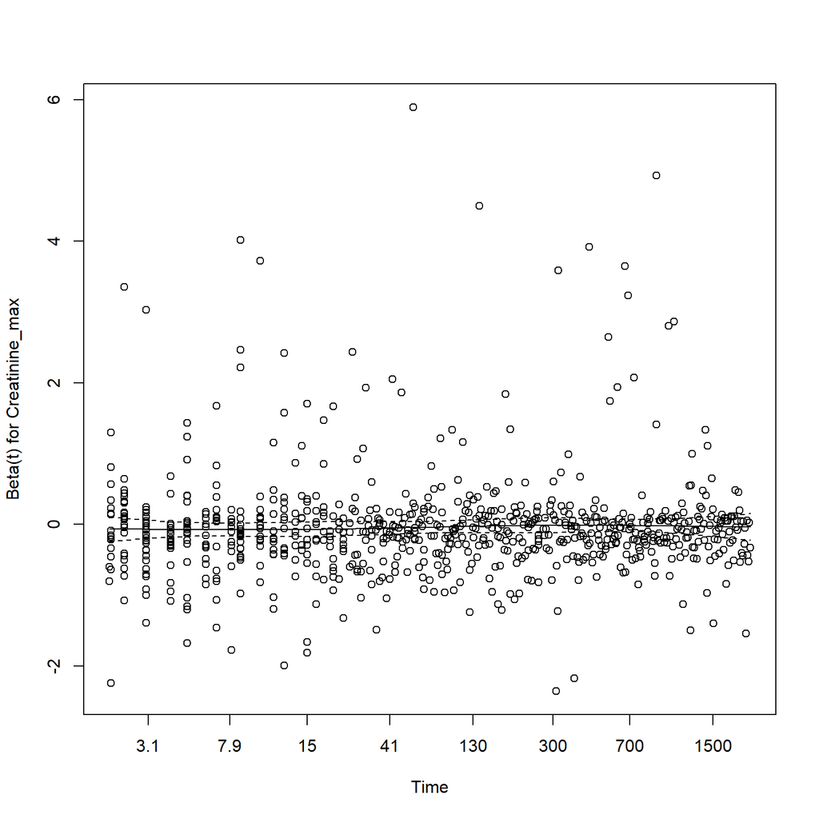

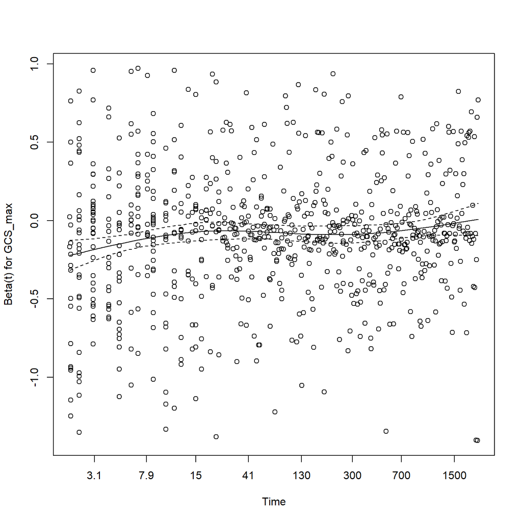

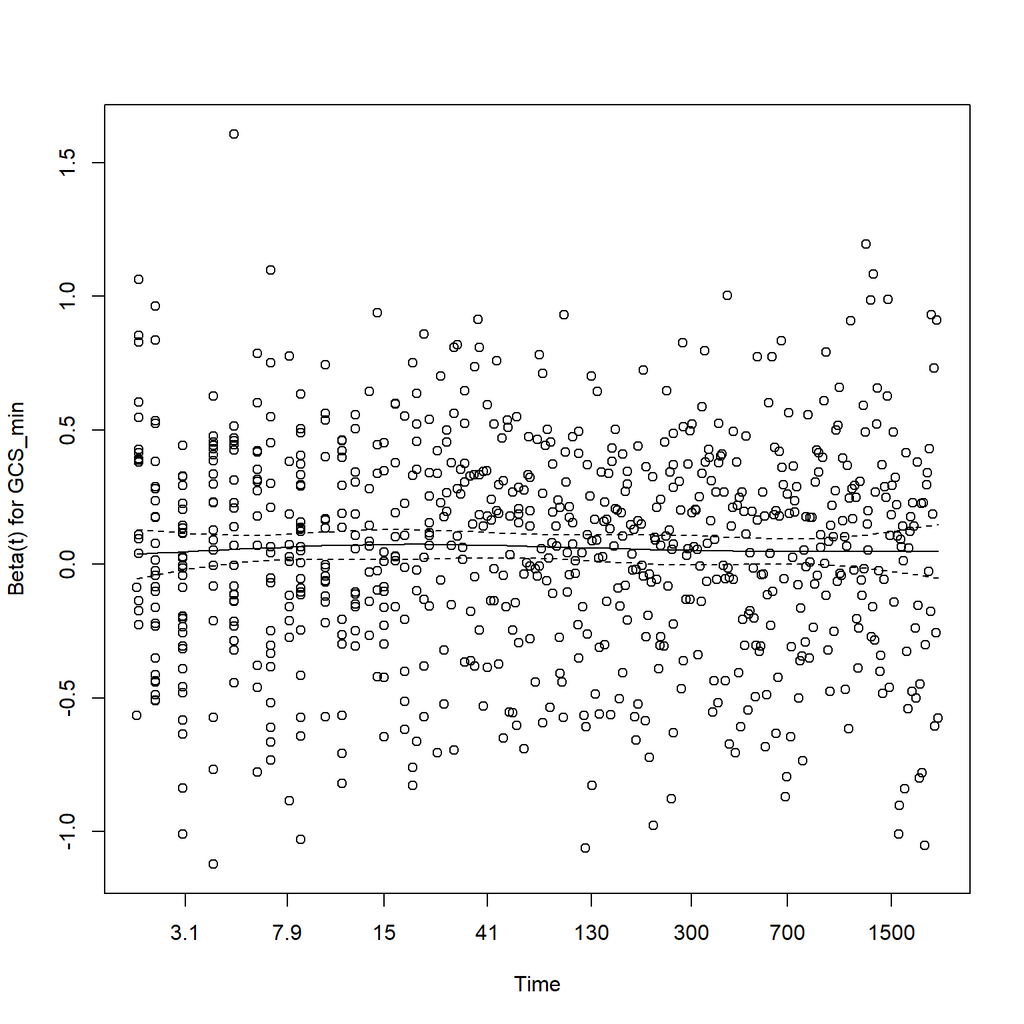

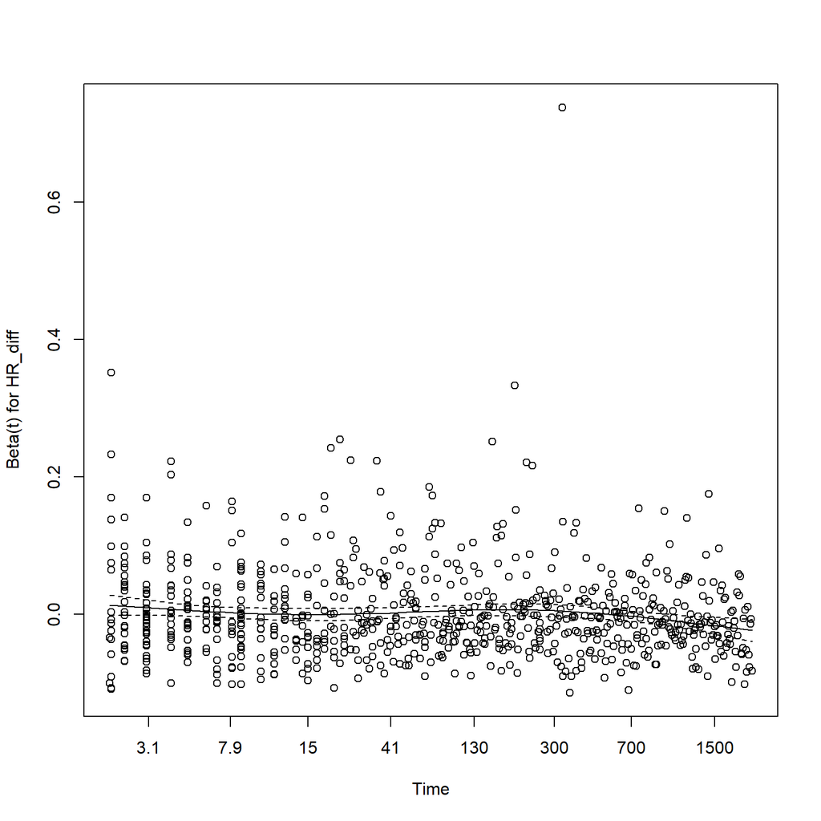